# Yelp Trends

Foodie: Avery Kan, Jingya(Elly) Wang, Yujie Wang, Xuyu Zhang, Haochen Zhou

May 7, 2016

### Introduction

Nowadays, Yelp is an inevitable part of our lives. It provides first-hand business information and serves as a platform to rate and share experiences, so it is not surprising that Yelp also has an enormous database containing information of key features of businesses such as reviews, stars, ambience and other critical information. This database not only allows consumers to make wise decisions but also businesses to receive interactive feedback.

In this project, we limited our scope into restaurants and examined different relationships between ratings, income, state and type of food. Through our experiences with Yelp, we noticed that ratings and reviews are two key factors in potential customers’ decision making processes. Thus we identified three key questions:

1. What is the relationship between regional income and the resturants’ average ratings?
2. What is the relationship between the type of restaurant and its price range?
3. What is the relationship between the type of restaurant and their average ratings?

Prior to answering these questions, we created maps of income by quartiles and number of restaurants by these income quartiles which clarifies the situation.

In answering the questions proposed, we converted the JSON file from Yelp into tidy tables and then divided regions into six states: AZ, IL, NC, NV, PA, and WI. We separated different cuisines into six types of restaurants: African, American, Asian, European, Latin American, Middle Eastern. For each state, we examine the relationship between each type of restaurant and factors such as price range and income. To visualize and analyze the results, we used a variety of plots such as barplots, scatter plots, boxplots, density plots and maps. The variety of plots enables us to have a better understanding of the relationships and make insightful analysis.

Since the six types of restaurants we identified covers most cuisines, it is helpful for us to know people’s preferences for each type of food in different states. Moreover, it is interesting to discover the relationship between income and ratings because it helps us uncover whether socioeconomic status affects ratings.

### Data Collection

In order to collect data about Yelp reviews, we used the data from the [Yelp Dataset Challenge](https://www.yelp.com/dataset_challenge). The data were initially contained in two large JSON files, which include 2.2 million reviews, 591k tips by 552k users for 77k businesses. One of the JSON files contained business information such as business ID, full address, categories, neighborhood, city, state, and other attributes of the businesses such as the ambience, price range, food type, stars etc. The second JSON file contained review information, such as business id, reviewer id, rating, and text of the review. Overall, the data is sourced from 10 large cities (Edinburgh, Karlsruhe, Montreal, Waterloo, Pittsburg, Charlotte, Urbana-Champaign, Phoenix, Las Vegas and Madison) from 4 different countries (U.K, Germany, Canada and U.S.) With a large dataset and detailed information for the businesses, we seek to comprehensively analyze the relationships between ratings, income, type of food the restaurant offers, and location of the restaurants on Yelp.

Since JSON files are not R-friendly, we used Python to convert them into csv files (Appendix Part I), which are then imported into R for data cleaning and analysis. The focus of our project is only on those restaurants in the United States. Therefore, from the initial imported csv data frames, we joined the review data frame with the businesses data frame and created a tidy data table called `restaurants`, filtering out the businesses that had a “restaurants” tag in the categories and addresses with US zip codes (Appendix Part II).

For the purpose of our analysis, we grouped more than 50 categories of food into 6 main groups: African, American, Asian, European, Latin American, Middle Eastern and other (Appendix Part II). For each restaurant, we indicated whether the restaurants fell into any of the categories with `TRUE` and `FALSE` indicators, then we filtered the factors into a categorical variable called `Type`, which includes restaurants with at least one categorical indicator as true.

In addition to the Yelp’s data set, we also collected the mean and median household income information from the [University of Michigan’s Population Studies Center](http://www.psc.isr.umich.edu/dis/census/Features/tract2zip/).The data provided us with household income information for each zip code region. Therefore, we are able to import this dataset into R and join it with our big data table for restaurants.

With the addition of income information and binary variables for each category of food, we are able to move onto next step of data visualization and analysis. Please see table 1 our final data table.

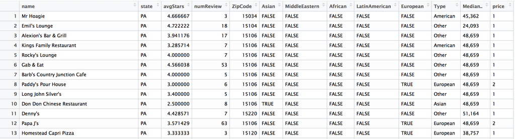

## Analysis and Visualization

#### Part 1: Maps of Income Quartiles and Average Ratings

How do the average ratings of restaurants in each region of the state compare with the median income in the given region? We will be looking at the map of the average ratings and the map of income for each metropolitan area side by side and see if we can find any interesting relationship between the two factors. To graph the average ratings on maps of metropolitan areas, we calculated the average ratings for restaurants in each zip code region and used the [choroplethr package](https://github.com/arilamstein/choroplethrZip) to help us with the plots. For the income data, we divided all income into 4 quartiles, using the data for 1st quarter, median, and 3rd quarter levels as dividing points. By using the choroplethr package, we were able to also graph the median household income on maps of the metropolitan areas and compare it with the average ratings map side by side.

##### Charlotte Metropolitan Area

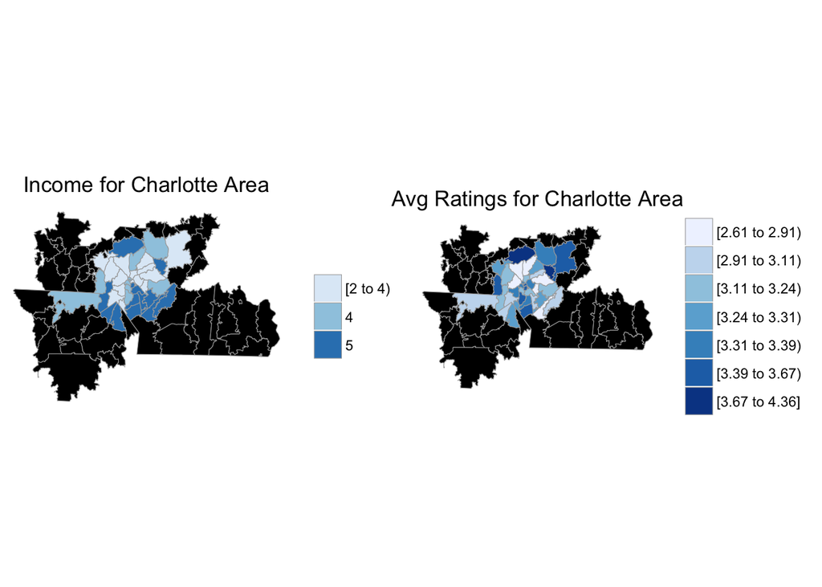

First, we looked at the maps for Charlotte, NC. By looking at the graph of income and average ratings side-by-side, we observed that income and average ratings do not seem to have an apparent, consistent correlation. Northwestern and Northeastern parts of Charlotte is in the lower quartile for income, but the rating of restaurants there is slightly above average. The southern part of Charlotte has both fairly high earning communities and also highly rated restaurants. In other parts of Charlotte, the ratings and income are both around average. The lack of obvious correlation shown in Charlotte is probably explained by the fact that Charlotte communites are fairly connected and small, so people could easily travel to other zip code regions for food. As a result, there would not be an obvious relationship between income quartile and the average ratings of restaurants.

##### Pittsburgh Metropolitan Area

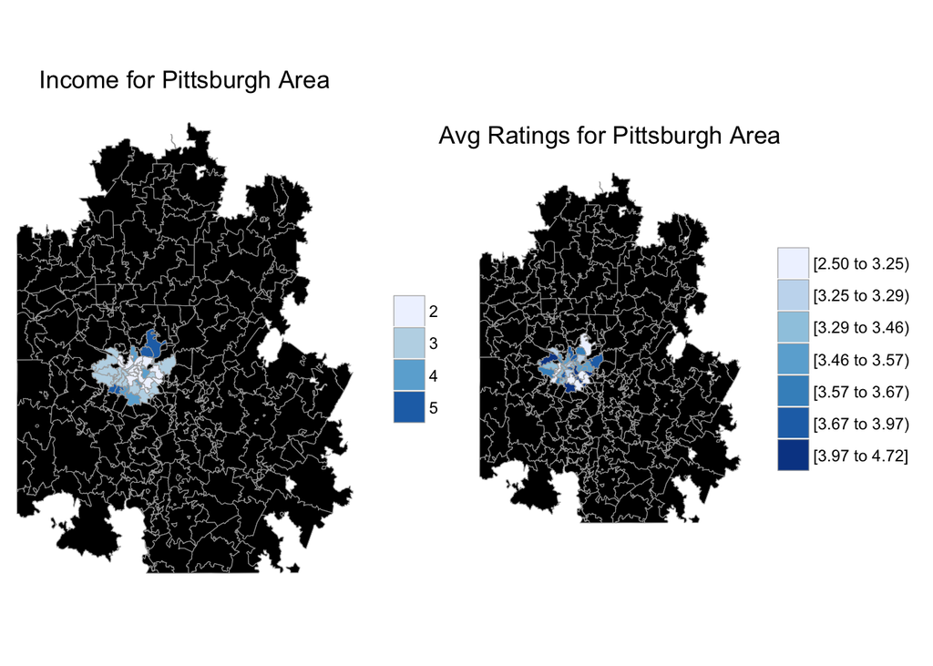

Next, we looked at Pittsburgh, which is located in the Northeast part of the country. Looking at the graphs closely, we noticed that the middle part of the city has generally above average ratings for restaurants. However, the income quartile is the lowest for that part of the city. We believe that this is caused by the fact that the downtown region is mostly commercial centers with very few residents. Therefore, the restaurants there generall have above average ratings due to convenient location but the there is very few residents there to balance out the possible homeless communites for income. The northern and southern parts of Pittsburgh seems to be fairly rich, but the rating data is mostly missing. This suggest that those areas are mainly residential and have very few restaurants.

##### Madison Metropolitan Area

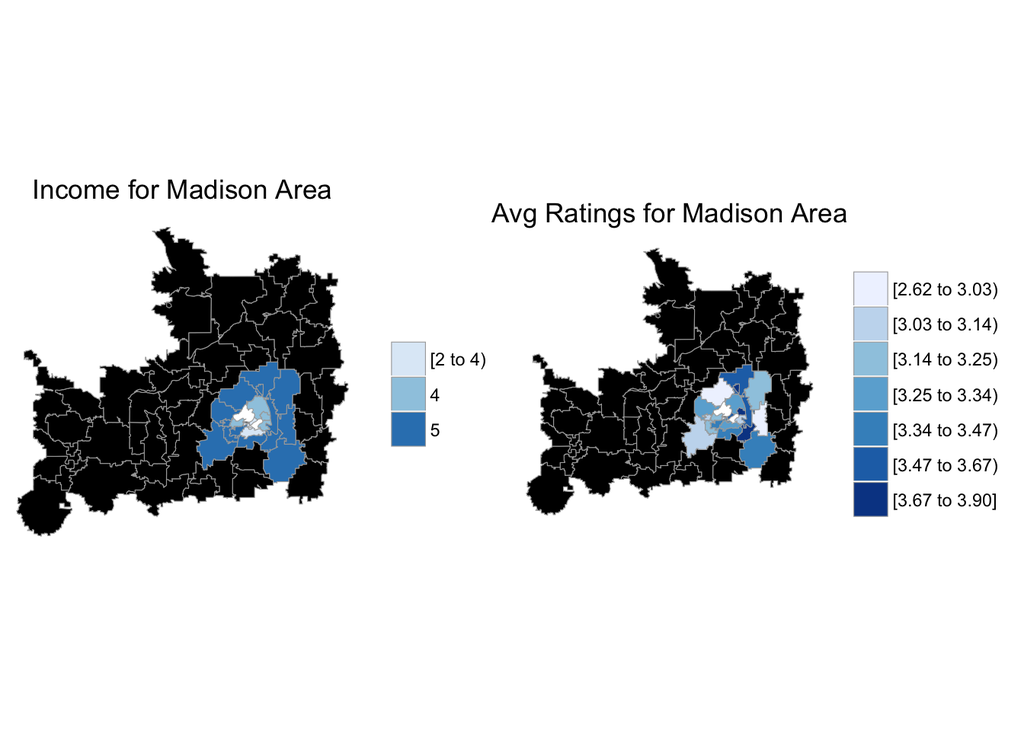

Moving towards the Midwest, we looked at Madison, WI. From the household median income graph, we noticed that the suburbs of Madison are placed in the top quartile of income, indicating a region with fairly high earnings. Comparing to the map of the average distributions, we don’t see the same pattern. Instead, we noticed that there’s a strip of region in the middle that has above average ratings. The lack of similarities in the distribution, again, concludes to the fact that there probably isn’t a clear relationship between the income and average ratings of the restaurants in that area.

##### Urbana-Champaign

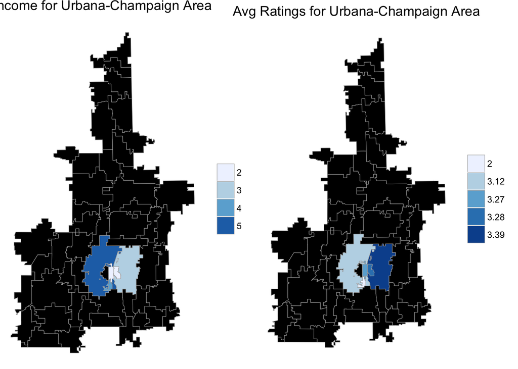

Next, we looked closely at a college town in Illinois– Urbana Champaign. Comparing and contrasting the colors of each part of the maps, we observe that the two large regions in Urbana-Champaign area show opposite shades of blue, indicating that the higher income area has relatively low average ratings for restaurants in that region. This result is interesting because we expected richer regions to have higher rated restaurants too, since restaurants in rich regions are usually relatively high-class and have to live up to higher standards of the rich people living in that region. However, we realized that the results we obtained may be due to difference between commercial and residential regions.

##### Las Vegaas

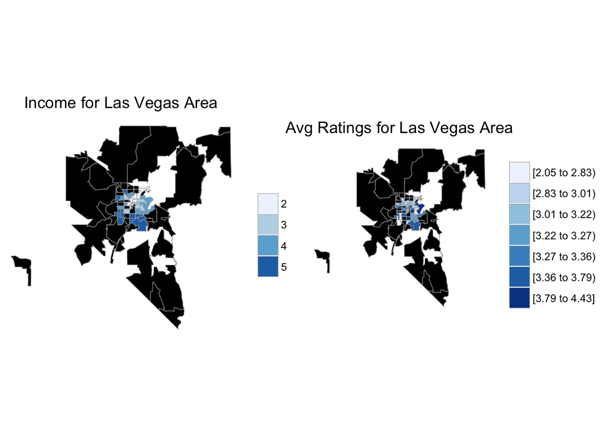

Next, we moved on to looking at the relationship between income and average restaurant ratings for Las Vegas. Looking at the graph for income and average ratings for Las Vegas Area, we can observe that in general, restaurants’ ratings are consistent with the median house income in the region, noting that the majority of the ratings and income are above average. Especially in Southern part of Las Vegas, income and ratings are both a lot higher than average. The general above average income and ratings in Las Vegas can be explained by the nature of the city. Las Vegas, as we all know, is a popular tourist location, especially for the casinos and resorts. Therefore, the cities’ income is generally high from tourism, and the ratings are fairly high because of the large amounts of reviews and high standards that the restaurants have to live up to for being located in a popular tourist city.

##### Pheonix

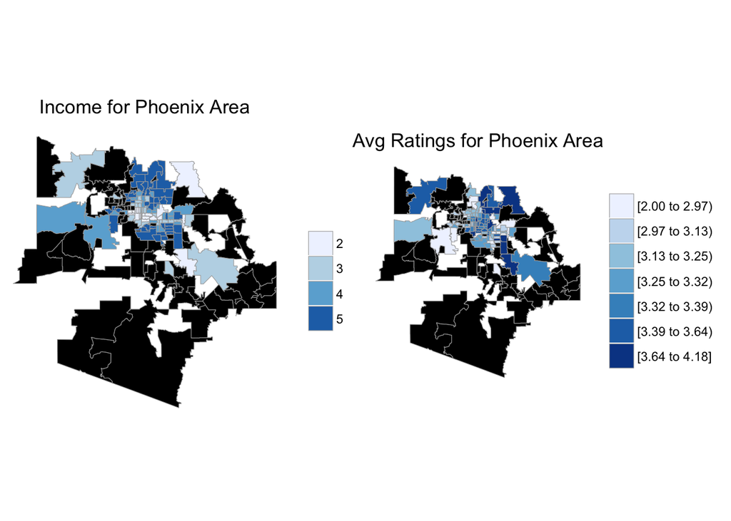

After looking at the income and average ratings for each of the six metropolitan areas, we concluded that there’s no clear relationship between the two variables due to the fact that ratings are probably affected by other factors such as type of food and the location of the restaurant relative to commercial centers. Therefore, in the next few sections, we will zoom in on each type of food and see if there are any relationship we can find between ratings, income, and the type of food.

#### Part 2. Number of each type of restaurants in each income regions

From previous section, we find that there’s no clear relationship between income and average ratings of the restaurants. Therefore, in this section, we will look and see if there is some trends between the median household income and the number of each type of restaurants in a given region.

With our data table, we grouped the data by income quartiles and type of food, then aggregated the counts for each category. See table 2 for the resulting data table.

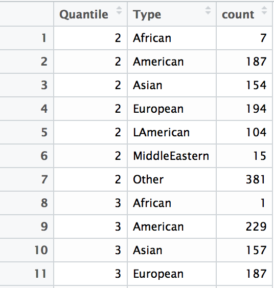

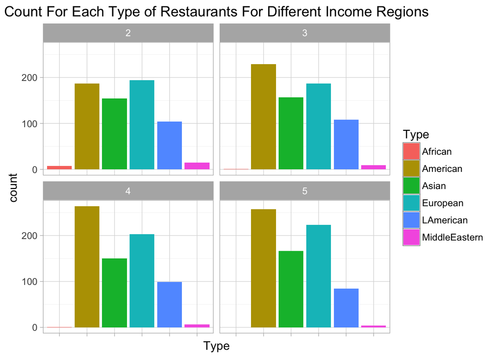

Of course, the counts of each type of restaurants in each income quartile regions cannot give us a complete picture of how rating could be affected by food type or income, so next we will take a look at the relationship between the type of restaurant and their price ranges.

#### Part 3. Average Price Range and Type of Restaurants

Regardless of the location, the affordablity of the food is an important criteria when it comes to rating. For our next step, we looked at the price ranges of each type of food in each state.

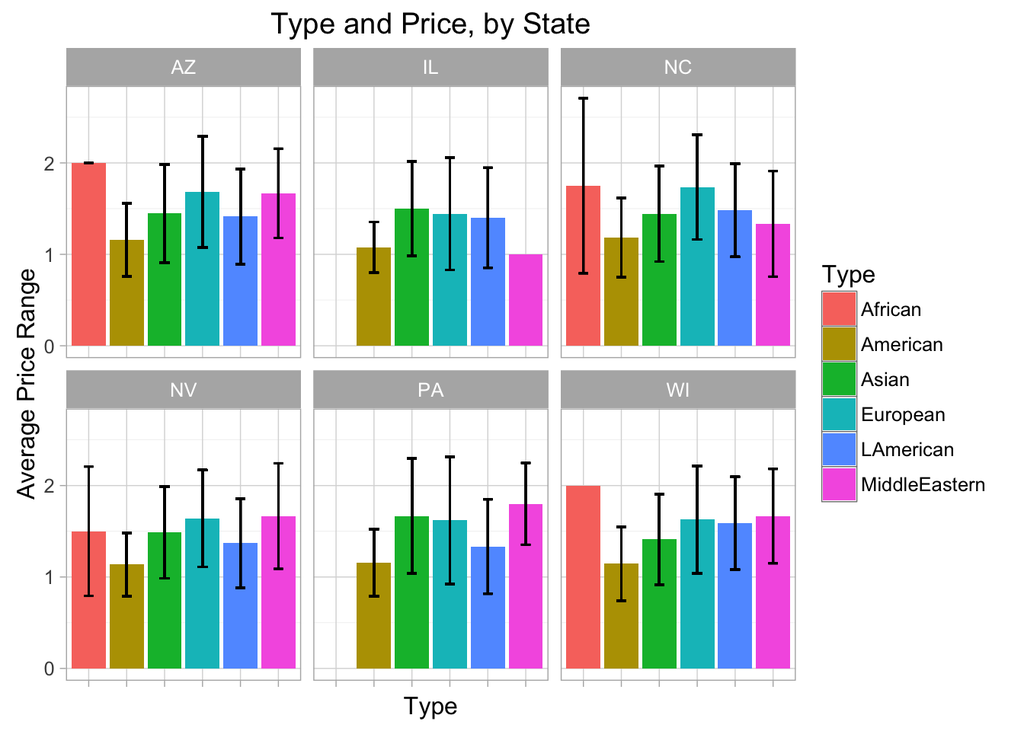

On the other end of the spectrum, American cuisine is the cheapest overall, in part due to its widespread presence, low costs of production, and being more readily integrated into the local restaurant scene. However, as we will inspect in the next section, the overarching umbrella of “American” cuisine carries many uncertainties in part due to wide regional variations in consumption habits. We can also ask ourselves- What exactly is American cuisine? An image that presents itself is that of the fusion and mixture of cultures and customs that make up the diverse image of modern American society.

[figure not shown]

#### Part 4: Average Ratings and Type of Restaurants

With price range trends for each type of restaurants in mind, we moved on to look at the average ratings for each type of restaurants.

What is the relationship between the average ratings and type of restaurant for each state? Which type of food has the highest or lowest average rating in each state? Are the average ratings consistent regardless of type of restaurant and state? Or do average ratings depend on type of restaurant and state?

Theoretically, average ratings vary in states by different types of restaurants. For example, we assume that in states that have high Asian population, average ratings may be higher for Asian restaurants than African restaurants. However, does the reality prove our assumption? Quantitatively, we rated the restaurants on the scale of 1 to 5, as shown on the y-axis, and used box plots to compare the average ratings for each type of restaurants and to explore the relationship between them.

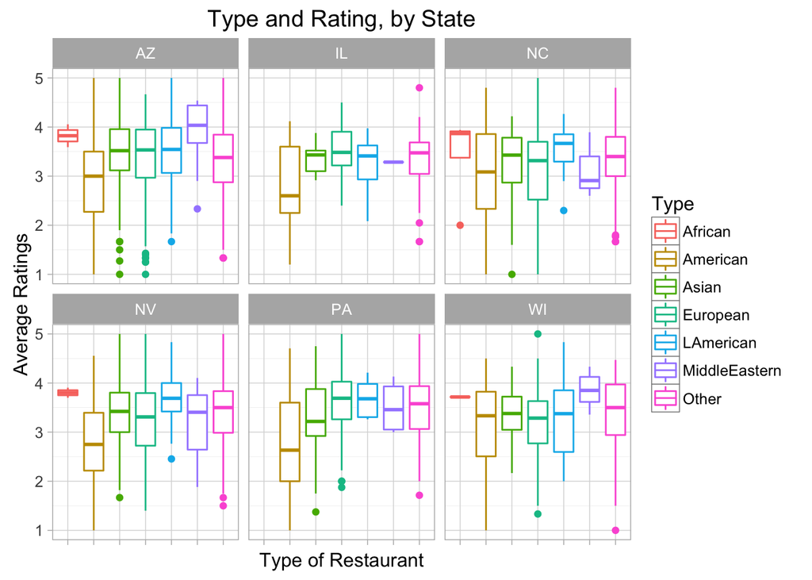

Lastly, we noted the most popular type of restaurants for each state: Arizona and Wisconsin favour Middle Eastern restaurants; Illinois favours European restaurants; and North Carolina and Nevada both rate African food highly. In Pennsylvania, European and Latin American restaurants have the highest ratings.

It is interesting to note that except for WI and NC, American restaurants have the lowest rating. Considering the sample size of our data, we believe that there could be many other factors that are contributing to the results that we did not account for.

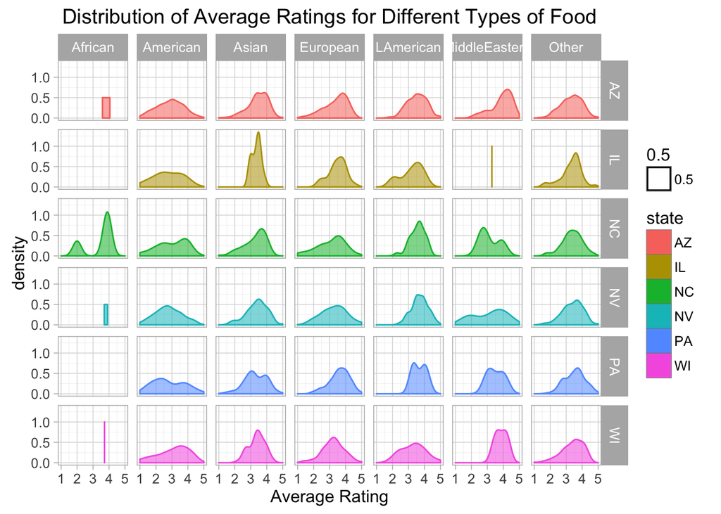

This plot can serve as a complement for our analysis above. In this graph, we looked at the distribution of the ratings for each type of restaurant in each state, using density plot. The density plots allowed us to see the sepcific distribution of ratings. For example, we find that the African food in North Carolina is bimodal, something that we did not observe from the box plot. In additon, we see that Asian Food in IL is consistently above average, since most of the area is located between 3 and 4 stars.

#### Part 5. Average ratings and Income

Having looked at the average ratings for each type of restaurants, we added income back in our graphs to observe the relationship between average ratings and income.

What is the relationship between average ratings and income if we graph them by the type of food? Do people who have higher income tend to give higher average ratings for restaurants or are ratings not correlated with income?

Theoretically, we assumed that people with higher income are more picky with food, and therefore, would give lower average ratings. For example, people with higher income will more likely take more factors into consideration such as environment and parking, etc. when giving reviews. Graphically, we plotted the average rating of each restaurant against the income, faceting the graph by type of food to explore the relationship between average ratings and income, holding the type of restaurant constant.

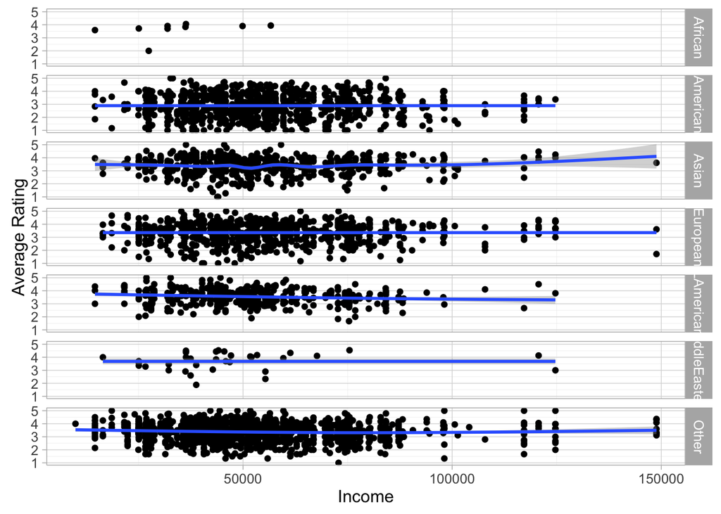

In order to make our observations more convincing, we divide restaurants into four price ranges from the lowest to the highest (1, 2, 3, 4, NA) as labelled on the scatter plot below. The division of different price ranges of restaurants enables us to explore a new topic: Does price range affect people’s average ratings on different types of restaurants (African, American, Asian, European, Latin American, Middle Eastern)?

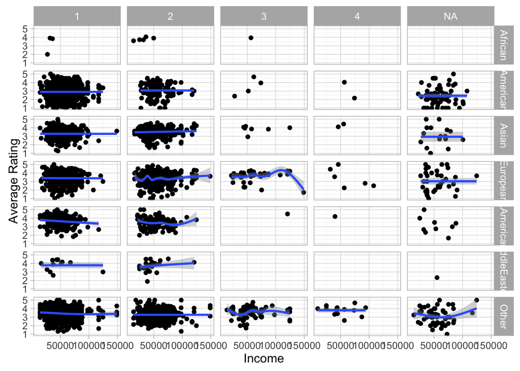

1. People’s income does not affect their taste for food. People who have higher income may enjoy a certain type of food as much as people with lower income. For example, those who eat in fancy, high-end restaurants enjoy fast food as much as those who have lower income and rarely eat at fancy restaurants.
2. People who have higher income and people who have lower income may go to restaurants that does not correspond to their income and consumption level. Thus, the effect of income and price range of different types of restaurants on people’s average ratings is minimized.
3. People are more likely to give restaurant higher rating based on the quality and price combined. For example, if the food is priced reasonably, meaning the quality of the food is up to the price standard, then people are more likely to give higher average reviews.
4. People do not usually go to restaurants within their own zip codes. People who have higher income may travel across zip code regions to other restaurants. For example, some people live in rich areas, but they may go to other neighborings area to explore different kinds of food. As cars and ride sharing services become more prevalent, people are no longer restricted to the region in which they live in for food.

Overall, ratings reflect individual experiences, transitive and in the moment, rather than a long term trend.

### Conclusion

By cleaning and plotting the data that we had collected from Yelp and the Census Bureau/University of Michigan’s Population Studies Center, we were able to explore relationships among restaurants’ average ratings, location, types of food served, price range, and median household income for the restaurant’s location. With the data visualizaton and analysis we have done, we are able to conclude that there is no apparent relationship between income and average ratings for each type of food in each state. In other word, the median household income in an area does not affect the restaurants’ ratings in that area, regardless of the type of restaurant and its price range.

Along the way, we also had some interesting discoveries regarding each type of food and their repsective popularites in each state. For example, we found that African restaurants have the relatively higher rating than other types of food, while also being the rarest type of food across the six metropolitan areas that we havestudied. We also found that average ratings for American restaurants has the biggest variation when compared to other food types.

Our findings are interesting and proved many of our initial assumptions wrong. Through data visualizaton and analysis, we also had other interesting findings regarding the ratings and price for each type of restaurants. Although we had a rich discovery, there is still a lot to explore other factors that relate to average ratings. It will be interesting to incorportate more demographic data to explore the relationship between race and average ratings of their own types of food. For example, will Chinese give higher ratings to Chinese food in certain areas? We can even connect our findings to the questions in order to have a more holistic view of the average ratings. It may serve as a starting point for continuous study of the topic.

### Appendix

#### Part I: JSON to CSV python code

```r
import json
import csv
import codecs

###########
# Reviews #
###########

i =0;
for line in open("yelp_academic_dataset_review.json", 'r'):
    reviews_parsed.append(json.loads(line))
    i = i + 1
    if(i == 350000):
        break;

all_data = []

for item in reviews_parsed:
    all_data.append(item)

review_data = open('Complete.csv', 'w')
csvwriter = csv.writer(review_data)

count = 0

for review in all_data:
    if count == 0:
        header = review.keys()
        csvwriter.writerow(header)
        count += 1
    csvwriter.writerow([unicode(val).encode("utf-8") for val in review.values()])
review_data.close()


############
# Business #
############

business_parsed = []
i =0;
for line in open("yelp_academic_dataset_business.json", 'r'):
    business_parsed.append(json.loads(line))
    i = i+1

B_data = []

for item in business_parsed:
    B_data.append(item)

business_data = open('CheckIns.csv', 'w')
csvwriter3 = csv.writer(business_data)

count = 0

for business in B_data:
    if count == 0:
        header = business.keys()
        csvwriter3.writerow(header)
        count += 1
    csvwriter3.writerow([unicode(val).encode("utf-8") for val in business.values()])

business_data.close()
```

#### Part II: Code for data cleaning:

```r
#Import necessary libraries
library(DataComputing)
library(geosphere)
library(ggthemes)

##PART 1
#Import Data from CSV files
bdata <- read.csv("/Users/EllyWang/Documents/School/Stats 133/Yelp/Businesses.csv")
cdata <- read.csv("/Users/EllyWang/Documents/School/Stats 133/Yelp/Complete.csv")
MedianIncome <- read.csv("/Users/EllyWang/stat-133/ZipMedianIncome.csv")

##PART 2: Joining data tables and create necessary variables
#Join Restaurants and Average Reviews
id_stars <- cdata %>% group_by(business_id) %>%
  summarize(avgStars = mean(stars, na.rm=TRUE), numReview = n())
bdata <- left_join(bdata, id_stars, by= c("business_id"= "business_id"))

#Add Zipcode
bdata <- bdata %>%
  extractMatches("[:space:]([:digit:]+)$", full_address, ZipCode=1)
bdata$ZipCode <- strtoi(bdata$ZipCode)
bdata <- bdata %>% filter(ZipCode>10, !is.null(ZipCode))

#Clean categories, remove unnecessary marks
bdata <- bdata %>%
  mutate(categories = gsub("'|^//[|//]$|","",categories)) %>%
  mutate(categories = gsub("^u","",categories)) %>%
  mutate(categories = gsub(", u", "," ,categories))

#Filter out restaurants
restaurants <- bdata[grepl("Restaurants", bdata$categories),]


##PART 3: Add Categories

#Function that puts TRUE if category is present for the given business
checkcategory <- function(category){
  #pattern = paste("(", category, ")", sep="")
  pattern = paste(category, collapse = "|")
  Categories <- grepl(pattern, restaurants$categories)
  return(Categories)
}

#Create 6 Large Categories for Food Types
asianf <- c("Asian Fusion","Chinese","Dim Sum", "Laotian", "Filipino",  "Indian", "Japanese", "Vietnamese", "Korean", "Sushi Bars", "Thai", "Himalayan/Nepalese", "Indonesian", "Mongolian")
mideastf <- c("Middle Eastern", "Afghan", "Falafel", "Kosher", "Pakistan", "Persian/Iranian", "Lebanese")
africanf <- c("African", "Ethiopian", "Soul Food", "Moroccan")
americanf <- c("American(New)", "American(Traditional)","Cajun", "Hawaiian", "Southern", "Burgers", "Fast Food", "Hot Dogs", "Sandwishes")
latinamericaf <- c("Latin American", "Caribbean", "Cuban", "Mexican", "Peruvian", "Argentine", "Colombian")
europef <- c("Belgain", "French", "German", "Greek", "Hungarian", "Irish", "Italian", "Mediterranean", "Polish", "Portuguese", "Russian", "Spanish", "Pizza")

#Add columns indicators for each type of food
Asian <- checkcategory(asianf)
MiddleEastern <- checkcategory(mideastf)
African <- checkcategory(africanf)
American <- checkcategory(americanf)
LatinAmerican <- checkcategory(latinamericaf)
European <- checkcategory(europef)
restaurants <- cbind(restaurants, Asian, MiddleEastern, African, LatinAmerican,
                     European)

#Add variable Type
restaurants <- restaurants %>% mutate(Type = ifelse(American== TRUE, "American",
                                                    ifelse(Asian == TRUE, "Asian",
                                                           ifelse(MiddleEastern== TRUE, "MiddleEastern",
                                                                  ifelse(African == TRUE, "African",
                                                                         ifelse(LatinAmerican == TRUE, "LAmerican",
                                                                                ifelse(European == TRUE, "European", "Other")))))))

#Filter out those that have reviews
restaurants <- restaurants %>% filter(!is.na(numReview))

##PART 4: Add Income Information
#Adding Income
rest_Income <- left_join(restaurants, MedianIncome, by= c("ZipCode"= "Zip"))
restaurants <- rest_Income %>%
  extractMatches("([:digit:])",attributes, price=1)
```

#### Part III: Code for all the plots generated (code chunks are combined):

```r
##
#Part 1
##

ZipCodeRatings <- restaurants %>%
  group_by(ZipCode) %>%
  summarize(avgReview = mean(avgStars, na.rm = TRUE))

zip_state <- restaurants %>% select(ZipCode, state)
zip_state <- unique(zip_state)

ZipCodeRatings <- left_join(ZipCodeRatings, zip_state, by = c("ZipCode" = "ZipCode"))
ZipCodeRatings <- ZipCodeRatings %>% mutate(region = as.character(ZipCode))
ZipCodeRatings <- ZipCodeRatings %>% mutate(value = avgReview)


not_included_zip <- c(28246, 85218, 85219, 85220, 85222, 85228, 85232, 85239, 85242, 85358, 85378, 89152)
ZipCodeRatings <- ZipCodeRatings %>% filter(! region %in% not_included_zip)

restaurants <- restaurants %>% mutate (newvar = as.character(Median..))
restaurants <- restaurants %>% cbind(MedIncome= gsub(",", "",restaurants$newvar)) %>%
  mutate(MedIncome = strtoi(MedIncome))

quantiles <- quantile(restaurants$MedIncome, na.rm =TRUE)

Income_quart <- restaurants %>%
  mutate (Quantile = ifelse(MedIncome < quantiles[1], 1,
                            ifelse(MedIncome < quantiles[2], 2,
                                   ifelse(MedIncome < quantiles[3], 3,
                                          ifelse(MedIncome <quantiles[4],4,5)))))

Income_Zip <- Income_quart %>% mutate(region = ZipCode, value = Quantile) %>%
  select(region, value, state)
Income_Zip <- unique(Income_Zip)

#NC Maps
p1<-Income_Zip %>%
  filter(state == "NC") %>%
  mutate (region = as.character(region))  %>%
  zip_choropleth(msa_zoom = "Charlotte-Concord-Gastonia, NC-SC",
                 title = "Income for Charlotte Area")
p2<- ZipCodeRatings %>% filter(state == "NC") %>%
  zip_choropleth(msa_zoom = "Charlotte-Concord-Gastonia, NC-SC",
                 title = "Avg Ratings for Charlotte Area")
grid.arrange(p1,p2,ncol=2)

#PA Maps
p1<-Income_Zip %>%
  filter(state == "PA") %>%
  mutate (region = as.character(region))  %>%
  zip_choropleth(msa_zoom = "Pittsburgh, PA",
                 title = "Income for Pittsburgh Area")
p2<- ZipCodeRatings %>% filter(state == "PA") %>%
  zip_choropleth(msa_zoom = "Pittsburgh, PA",
                 title = "Avg Ratings for Pittsburgh Area")
grid.arrange(p1,p2,ncol=2)

#WI Maps
p1<-Income_Zip %>%
  filter(state == "WI") %>%
  mutate (region = as.character(region))  %>%
  zip_choropleth(msa_zoom = "Madison, WI",
                 title = "Income for Madison Area")
p2<- ZipCodeRatings %>% filter(state == "WI") %>%
  zip_choropleth(msa_zoom = "Madison, WI",
                 title = "Avg Ratings for Madison Area")
grid.arrange(p1,p2,ncol=2)

#IL Maps
p1<-Income_Zip %>%
  filter(state == "IL") %>%
  mutate (region = as.character(region))  %>%
  zip_choropleth(msa_zoom = "Champaign-Urbana, IL",
                 title = "Income for Urbana-Champaign Area")
p2<- ZipCodeRatings %>% filter(state == "IL") %>%
  zip_choropleth(msa_zoom = "Champaign-Urbana, IL",
                 title = "Avg Ratings for Urbana-Champaign Area")
grid.arrange(p1,p2,ncol=2)

#NV Maps
p1 <- Income_Zip %>%
  filter(state == "NV") %>%
  mutate (region = as.character(region))  %>%
  zip_choropleth(msa_zoom = "Las Vegas-Henderson-Paradise, NV",
                 title = "Income for Las Vegas Area")
p2<- ZipCodeRatings %>% filter(state == "NV") %>%
  zip_choropleth(msa_zoom = "Las Vegas-Henderson-Paradise, NV",
                 title = "Avg Ratings for Las Vegas Area")
grid.arrange(p1,p2,ncol=2)

#AZ Maps
p1<-Income_Zip %>%
  filter(state == "AZ") %>%
  mutate (region = as.character(region))  %>%
  zip_choropleth(msa_zoom = "Phoenix-Mesa-Scottsdale, AZ",
                 title = "Income for Phoenix Area")
p2<- ZipCodeRatings %>% filter(state == "AZ") %>%
  zip_choropleth(msa_zoom = "Phoenix-Mesa-Scottsdale, AZ",
                 title = "Avg Ratings for Phoenix Area")
grid.arrange(p1,p2,ncol=2)

##
#Part 2
##

numRest <- Income_quart %>% group_by(Quantile, Type) %>% summarize(count = n())


numRest %>%
  filter(Type != "Other", !is.na(Quantile)) %>%
  ggplot(aes(fill = Type, x= Type, y = count)) +
  geom_bar(position="dodge", stat="identity")+
  facet_wrap(~ Quantile, nrow= 2) +
  theme(axis.text.x = element_blank()) +
  theme_light() +
  labs(title = "Count For Each Type of Restaurants For Different Income Regions")


##
#Part 3
##

restaurants$price <- restaurants$price %>% as.numeric()
rest1 <-
  restaurants%>%
  group_by(Type, state) %>% mutate(avg = mean(price, na.rm= TRUE), sd= sd(price, na.rm = TRUE))

rest1 <-
  rest1%>%
  mutate(upper = avg + sd, lower = avg - sd)

p <- rest1 %>%
  filter(Type != "Other") %>%
  ggplot(aes(fill = Type, x= Type, y = avg)) +
  geom_bar(position="dodge", stat="identity")+
  facet_wrap(~ state, nrow= 2) +
  labs(y= "Average Price Range")

p <- p + geom_errorbar(aes(ymin = lower, ymax= upper),
                       position = "dodge" , width = 0.25) +
  ggtitle("Type and Price, by State")+
  theme_light()+
  theme(axis.text.x = element_blank())
p

rich <- rest1%>%
  filter(price > 2) %>%
  group_by(state, price) %>%
  tally(sort = TRUE)

count <- rest1 %>% group_by(state) %>% tally()

richcount  <-  inner_join(rich,count, by = "state")
richcount <- richcount %>% mutate(richratio = 100* n.x/n.y)

q <- richcount %>%
  ggplot(aes(state, richratio))+
  geom_point(size= 4, color= "darkgreen")+
  theme_light()+
  ggtitle("Expensive Restaurants, by State")+
  labs(x= "State", y= "percent 3 and 4 stars")
q


##
#Part 4
##

restaurants %>% ggplot(aes(Type, avgStars)) +
  geom_boxplot(aes(col = Type)) +
  facet_wrap(~state) +
  theme_light() +
  theme(axis.text.x = element_blank()) +
  labs(title = "Type and Rating, by State", x = "Type of Restaurant", y = "Average Ratings")


restaurants %>% ggplot (aes(avgStars)) +
  geom_density(aes(fill =state, color = state, alpha =0.5)) +
  facet_grid(state~Type) +
  theme_light() +
  xlab("Average Rating") +
  ggtitle("Distribution of Average Ratings for Different Types of Food")

##
#Part 5
##
restaurants %>%
  ggplot(aes(MedIncome,avgStars))+
  geom_point()+
  facet_grid(Type~.)+
  stat_smooth() +
  theme_light() + xlab("Income") + ylab("Average Rating")


restaurants %>%
  ggplot(aes(MedIncome, avgStars))+
  geom_point()+
  facet_grid(Type~price)+
  stat_smooth() +
  theme_light() +
  labs(x="Income", y="Average Rating")
```